# From zero to hero: raw data to mapped networks - 6 Network analysis

download all materials

## Mapping

##### Use the Network >> mapping module to create features to modify the network map bode and edge properties.

##### The following is an example of how to format and combine analysis for network mapping. Check out the [user manual](https://creativedatasolutions.github.io/dave.docs/partial/network.html#mapping) for more details about this module’s features.

### Methods

##### Use the `transformation` `map fold change` to format fold-change values (e.g. `FC_` results from the statistics module). This will create separate features for `FC_` magnitude(log2) and direction of change.

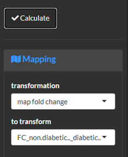

##### Select `calculate` and `save` to add the created features to the global data set.

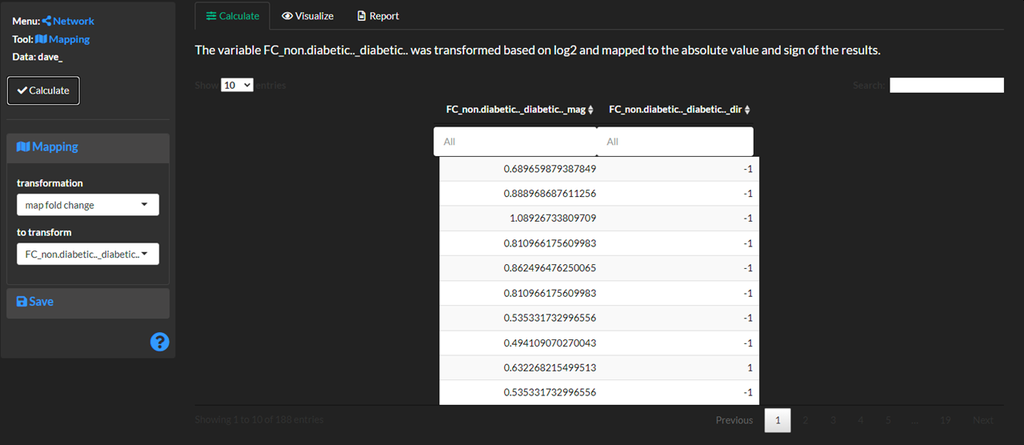

##### Use a similar procedure to format `p-values` and combine features.

##### Use `map p-value` to evaluate an `inequqlity` comparing a variable to a `threshold` value.

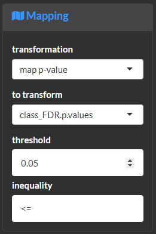

##### Use `combine columns` to concatenate variables multiple variables into a single feature. Note, save the created variables from `map fold change` and `map p-value` `transformations` before using in the `combine columns` `transformation`.

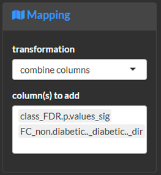

##### Select `calculate` to view the results then use `save` to add the created features to the global data set.

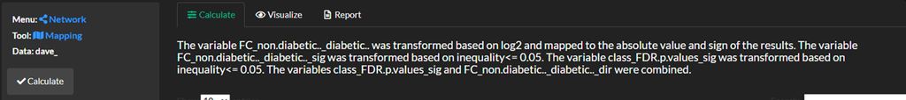

## Correlation analysis

##### Use the Network >> correlation module to calculate regularized correlations among all variables.

##### First, define the correlation `method`and `p-value` significance threshold and then select `calculate`.

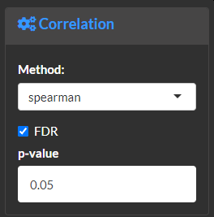

##### Next, use regularize to prune the network to maintain the most confident relationships. Use `optimization` to define the initial method (`ric` or `stars` Jiang et al. (2019)). Next, you can select the `manual` optimization and select a custom regularization `lambda` (the higher the more strict the selection).

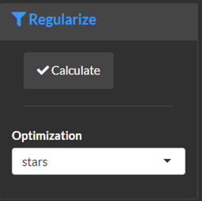

##### Select `calculate` and view the method results.

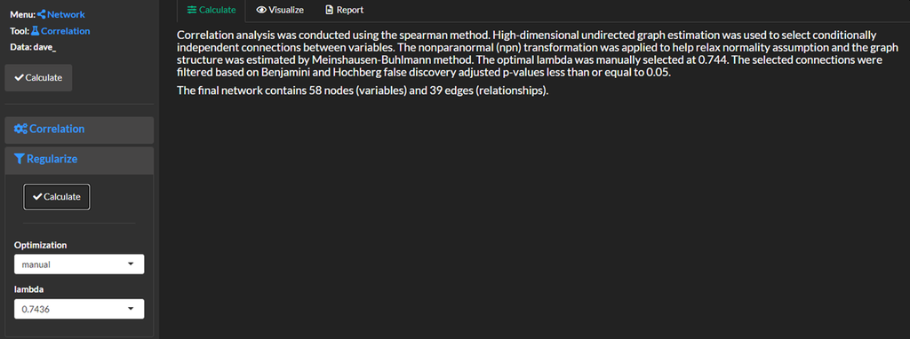

### Explore and plot

###### Use the Network >> visualize menu to create mapped networks integrated with the calculated relationships.

##### For example the following mapped network displays positive and negative regularized correlations and the following node properties:

##### - size = magnitude of fold-change

##### - color and shape = direction of fold change and if the statistical p-value met the threshold criteria set in mapping.

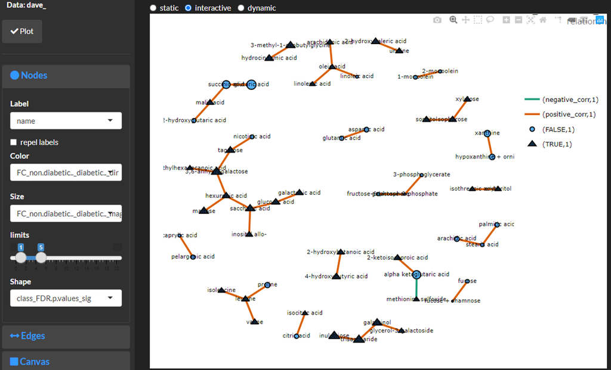

##### Use save to add the calculate network as an option to integrate with other available networks for the data set in network >> enrich.

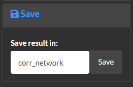

## Biochemical network

##### Use the Network >> biochemical module to calculate biochemical (substrate to product) relationships for all `KEGG` ids for metabolite measurements.

##### Define which variable in the data corresponds to the `KEGG` id or first use the network >> translate to translate it from metabolite names or other identifiers.

[figure not shown]

##### Next, `visualize`, create a `report` and save the calculated network.

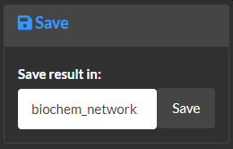

## Structural similarity network

##### Use the Network >> structural module to calculate molecule structural similarity relationships for all `PubChem CID` ids for metabolite measurements.

##### Define which variable in the data corresponds to the `CID` id or first use the network >> translate to translate it from metabolite names or other identifiers.

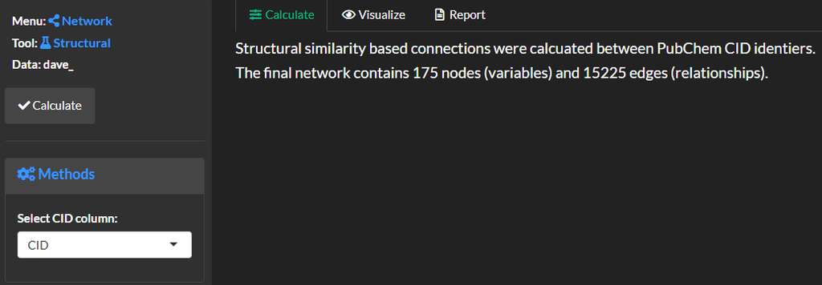

##### Next, `visualize`, create a `report` and save the calculated network.

## Network enrichment

##### Use the Network >> enrich module to combine, update and visualize the calculated networks.

##### Select networks which should be combined into a single network. Note, selecting `single edges` removes any duplicated connections keeping the first observed instance as defined by the order of the `selected networks`.

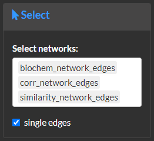

##### The update menu can be used to update the combined networks variable meta data (`_col_meta`).

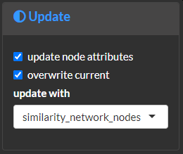

##### `Visualize`, create a `report` and save the calculated network.

##### Use the nodes menu to specify node labels, color, size and shape.

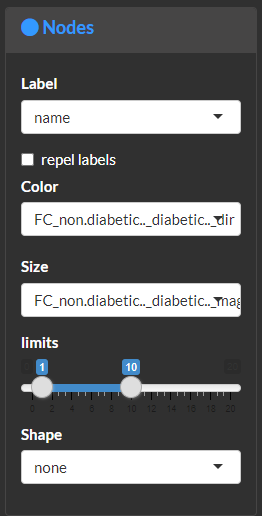

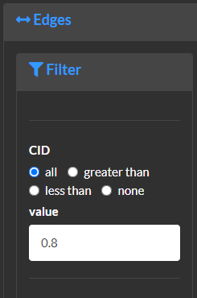

##### For example, the following `interactive` network displays the combined `biochemical`, `correlation` and `structural similarity` connections. The node size shows the magnitude of the fold change between `classes`. Node color encodes the direction and significance of the fold changes.

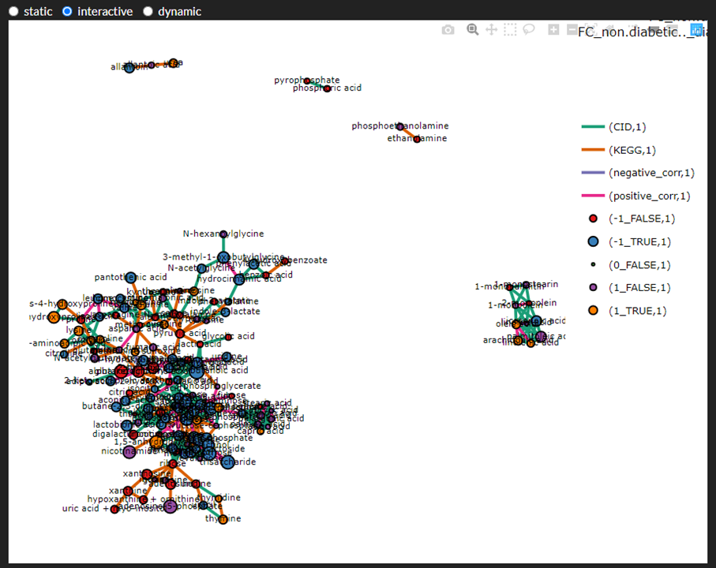

##### You can zoom and pan in the network and use the legend to filter the visualized nodes and edges. For example, the following subnetwork shows nodes for all significantly altered comparisons.

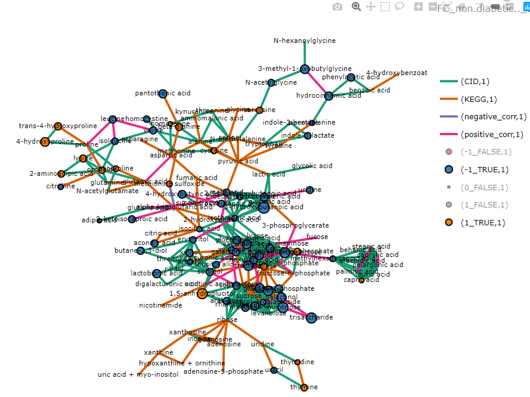

### Save and export

##### Save the created network to make it available for export.

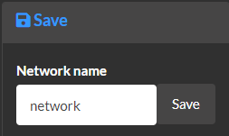

##### To continue optimizing the network using external tools, use the data module to export (save) the selected network `nodes` and `edges`.

Grapov, D., K. Wanichthanarak, and O. Fiehn. 2015. “MetaMapR: Pathway Independent Metabolomic Network Analysis Incorporating Unknowns.” Journal Article. *Bioinformatics* 31 (16): 2757–60. https://doi.org/10.1093/bioinformatics/btv194.

Jiang, Haoming, Xinyu Fei, Han Liu, Kathryn Roeder, John Lafferty, Larry Wasserman, Xingguo Li, and Tuo Zhao. 2019. *Huge: High-Dimensional Undirected Graph Estimation*. https://CRAN.R-project.org/package=huge.